# R Text Analysis for Moby Dick

Uriel Faier

## Introduction

Welcome to the Moby Dick Text Analysis Mini project! In this project, we preform some textual analysis on the famous book Moby Dick, using the R programming language.

### Project outline:

1. **Data Acquisition:** We’ll begin by extracting the complete text of Moby Dick from the Gutenberg project and preparing it for analysis.
2. **Word Frequency Analysis:** Next, we’ll delve into the distribution of word lengths, compute word frequencies, and identify the most common words in the text.
3. **Chapter Structure Examination:** We’ll analyze the chapter structure of Moby Dick, including word counts per chapter, and identify significant patterns or themes.

#### Data Acquisition:

Before we begin our analysis, we need to acquire the text of Moby Dick from the Gutenberg project. We’ll use the `rvest` package in R to Scrape and read the HTML content of the book’s webpage and extract the text.

```r
## Load necessary libraries
library(rvest)

## Define the URL for Moby Dick on Gutenberg
url <- "https://www.gutenberg.org/files/2701/2701-h/2701-h.htm"

## Read the HTML content of the webpage
md_html <- read_html(url)

## Extract the text of the book from the HTML content
md <- html_text(html_nodes(md_html, "body"))

## Extract the title of the book
title <- html_text(html_nodes(md_html, "title"))
```

#### Word Frequency Analysis:

Now that we have the text of Moby Dick, let’s analyze the distribution of word lengths and compute various statistics such as the median, mean, longest word, and most common word length.

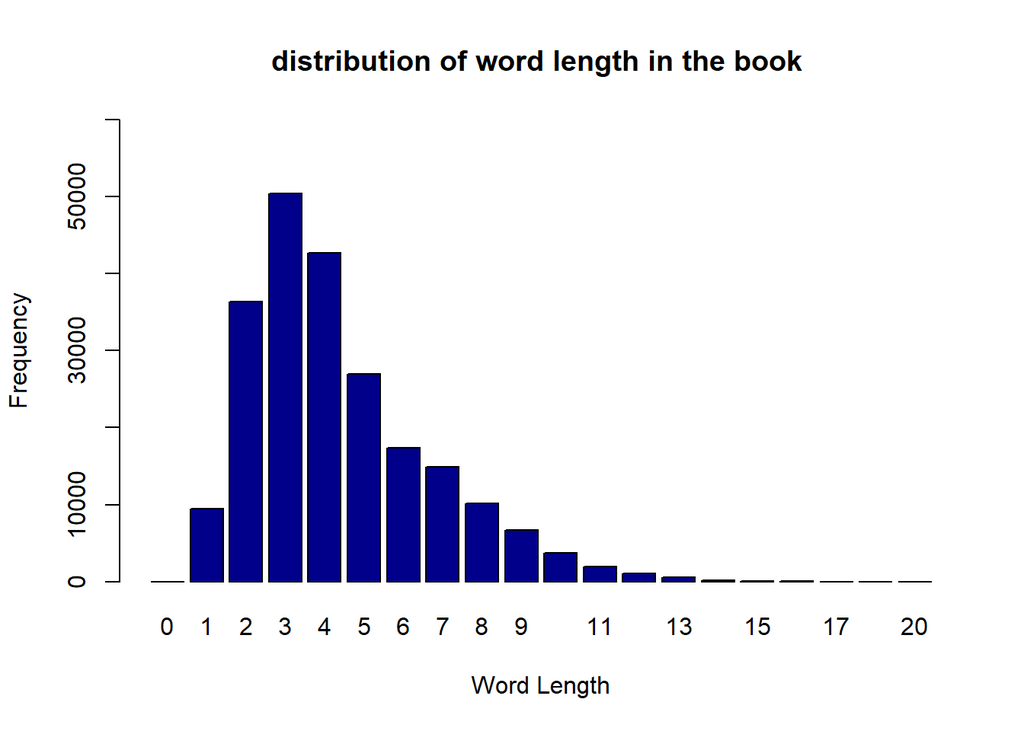

```r
## Split the text into individual words
per_word_split <- strsplit(md, "\\W+")[[1]]

## Calculate the number of words in the text
number_of_words <- length(per_word_split)

## Calculate the length of each word
len_per_word <- nchar(per_word_split)

## Create a bar plot showing the distribution of word lengths
barplot(table(len_per_word), col = "dark blue", ylim = c(0, 60000),
        main = "distribution of word length in the book ", xlab = "Word Length", ylab = "Frequency")
```

```r
## Calculate statistics on word lengths
median <- median(len_per_word, na.rm = TRUE)
mean <- mean(len_per_word, na.rm = TRUE)
longest <- max(len_per_word)
most_common <- names(sort(table(len_per_word), decreasing = TRUE)[1])

## Display the results
cat("\nThere are", number_of_words, "words in the text.\n")
```

```
##
## There are 222598 words in the text.
```

```r
cat("\nThe median length of words is:", median, "\n")
```

```
##
## The median length of words is: 4
```

```r
cat("The mean length of words is:", mean, "\n")
```

```
## The mean length of words is: 4.365282
```

```r
cat("The longest length of words is:", longest, "\n")
```

```
## The longest length of words is: 20
```

```r
cat("The most common length of words is:", most_common, "\n")
```

```
## The most common length of words is: 3
```

#### most frequent words:

Let’s compute the frequency of each word in the text and display the top 10 most frequent words.

```r
## Calculate word frequencies
word_frequencies <- table(per_word_split)

## Display the top 10 most frequent words
top_words <- as.data.frame(sort(word_frequencies, decreasing = TRUE))[1:10,]
top_words
```

```
##    per_word_split  Freq
## 1             the 13986
## 2              of  6704
## 3             and  6142
## 4               a  4649
## 5              to  4637
## 6              in  4004
## 7            that  3012
## 8             his  2474
## 9              it  2225
## 10              I  2123
```

As we can see the top 10 most frequent words in the book are words like “the” , “and” , “of” and so on .. this make sense and not a surprise seeing how we use these words all the time to build sentences.

#### Spliting the Text by chapter

Below, we created a list of 137 chapters of the book, including Etymology and Epilogue.

```r
chapters = strsplit(md, "\r\n    \r\n    \r\n      \r\n       \r\n    \r\n    \r\n      \r\n    \r\n      |\r\n\r\n      \r\n    \r\n      \r\n       \r\n    \r\n    \r\n      \r\n    \r\n      |\r\n     \r\n    \r\n      \r\n       \r\n    \r\n    \r\n      \r\n    \r\n      ")[[1]]
split_beginning = strsplit(chapters[1], "\r\n      \r\n      \r\n    \r\n      \r\n       \r\n      \r\n        \r\n      \r\n        ")[[1]]
split_ending = strsplit(chapters[137], "\r\n    \r\n\r\n")[[1]]
chapters[1] = split_beginning[2]
chapters[137] = split_ending[1]
```

#### Plot the number of words per chapter

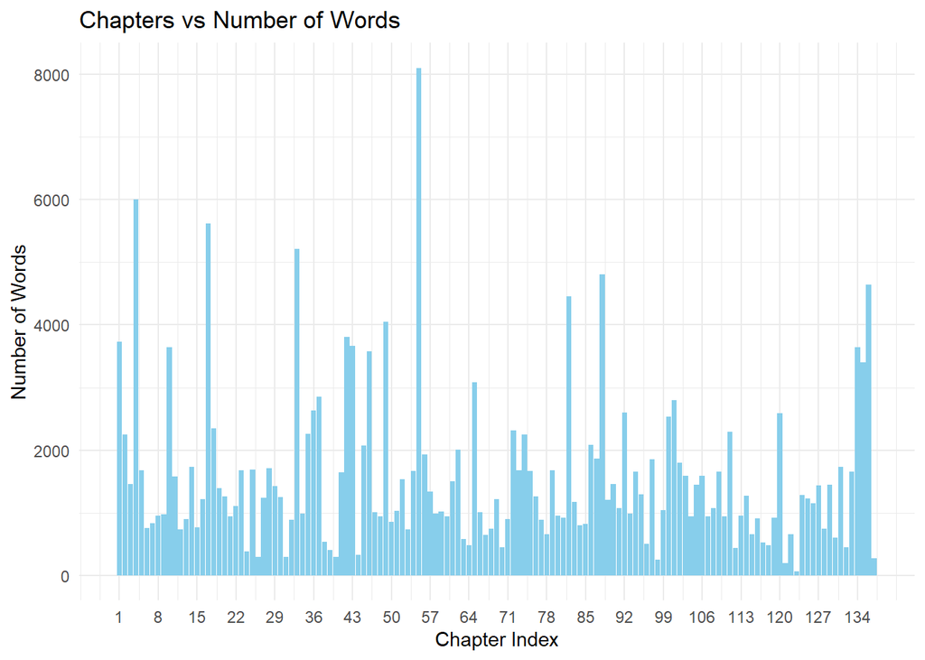

```r
# Initialize an empty vector to store the number of words in each chapter
num_of_words_vec = c()

# Create a sequence of chapter indices from 1 to 137
chapter_index = seq(1:137)

# Loop through each chapter in the 'chapters' list
for (chapter_j in chapters) {

  # Split the chapter text into individual words and count the number of words
  num_words_chapter_j = length(unlist(strsplit(chapter_j, "\\W+")))

  # Append the number of words in the current chapter to the 'num_of_words_vec' vector
  num_of_words_vec = c(num_of_words_vec, num_words_chapter_j)
}

# Create a data frame with chapter indices and corresponding number of words
df_chapters_q2a = data.frame(chapter_index, num_of_words_vec)

# Create a bar plot showing the number of words per chapter
ggplot(df_chapters_q2a, aes(x = chapter_index, y = num_of_words_vec)) +
  geom_bar(stat='identity', fill = "skyblue") +  # Plot bars with heights corresponding to the number of words
  scale_x_continuous(breaks =  c(seq(1, 137, 7))) +  # Set custom breaks for chapter indices
  ggtitle("Chapters vs Number of Words") +  # Set plot title
  labs(x = "Chapter Index", y = "Number of Words") +  # Set axis labels
  theme_minimal()  # Apply a minimal theme to the plot
```

#### Frequency of String per chapter

We’ve developed a function designed to compute a vector representing the relative frequencies of a specified string within each chapter of the book. This function allows us to analyze how the occurrence of a particular word evolves throughout the narrative, providing insights into its significance and usage patterns across different sections of the text.

```r
# Function to calculate the relative frequency of a specific word in each chapter of a book
freq_func_q2 = function(word_q2, chapters_q2) {

  # Initialize an empty vector to store the relative frequencies
  word_porportions_vec = c()

  # Loop through each chapter in the 'chapters_q2' list
  for (chapter_i in chapters_q2) {

    # Count the number of occurrences of the word in the current chapter
    true_in_i = str_count(chapter_i, as.character(word_q2))

    # Count the total number of words in the current chapter
    total_in_i = length(unlist(strsplit(chapter_i, "\\W+")))

    # Calculate the relative frequency of the word in the current chapter
    porportions_in_i = true_in_i / total_in_i

    # Append the relative frequency to the 'word_porportions_vec' vector
    word_porportions_vec = c(word_porportions_vec, porportions_in_i)
  }

  # Return the vector of relative frequencies
  return(word_porportions_vec)
}
```

#### Calculating the relative frequencies of “Ahab”, “Moby” and “sea” in each Chapter

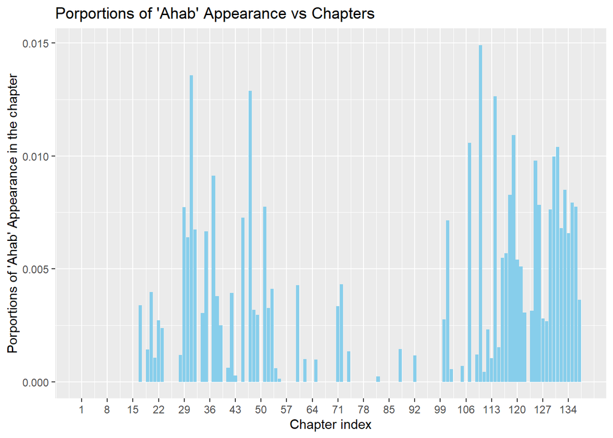

```r
# Calculate the relative frequencies of the words "Ahab", "Moby", and "sea" in each chapter
Ahab_q2_b = freq_func_q2("Ahab", chapters)  # Relative frequencies of "Ahab"
Moby_q2_b = freq_func_q2("Moby", chapters)  # Relative frequencies of "Moby"
sea_q2_b = freq_func_q2("sea", chapters)    # Relative frequencies of "sea"

# Create a data frame containing chapter indices and the relative frequencies of the words
df_words_q2_b = data.frame(chapter_index, Ahab_q2_b, Moby_q2_b, sea_q2_b)

# Create a bar plot showing the relative frequencies of "Ahab" in each chapter
ggplot(df_words_q2_b, aes(x = chapter_index, y = Ahab_q2_b)) +
  geom_bar(stat='identity', fill = "skyblue") +  # Plot bars with heights corresponding to relative frequencies
  scale_x_continuous(breaks =  c(seq(1,137,7))) +  # Set custom breaks for chapter indices
  ggtitle("Porportions of 'Ahab' Appearance vs Chapters") +  # Set plot title
  labs(x = "Chapter index", y = "Porportions of 'Ahab' Appearance in the chapter")  # Set axis labels
```

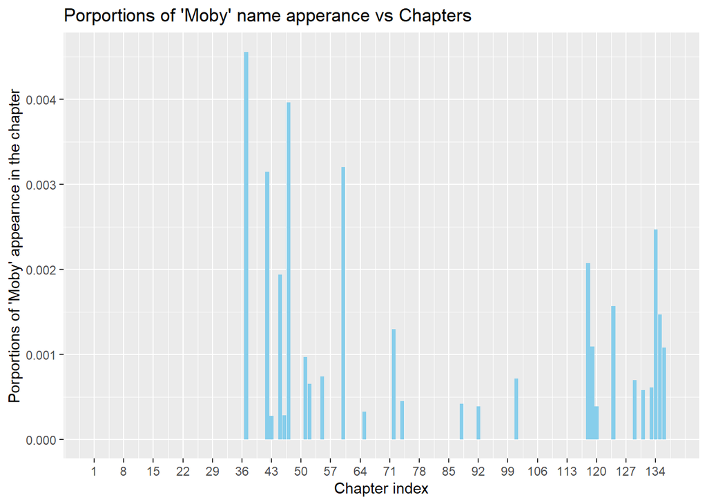

```r
ggplot(df_words_q2_b, aes(x = chapter_index, y = Moby_q2_b)) + geom_bar(stat='identity', fill = "skyblue") +scale_x_continuous(breaks =  c(seq(1,137,7))) + ggtitle("Porportions of 'Moby' name apperance vs Chapters") +
  labs(x = "Chapter index", y = "Porportions of 'Moby' appearnce in the chapter")
```

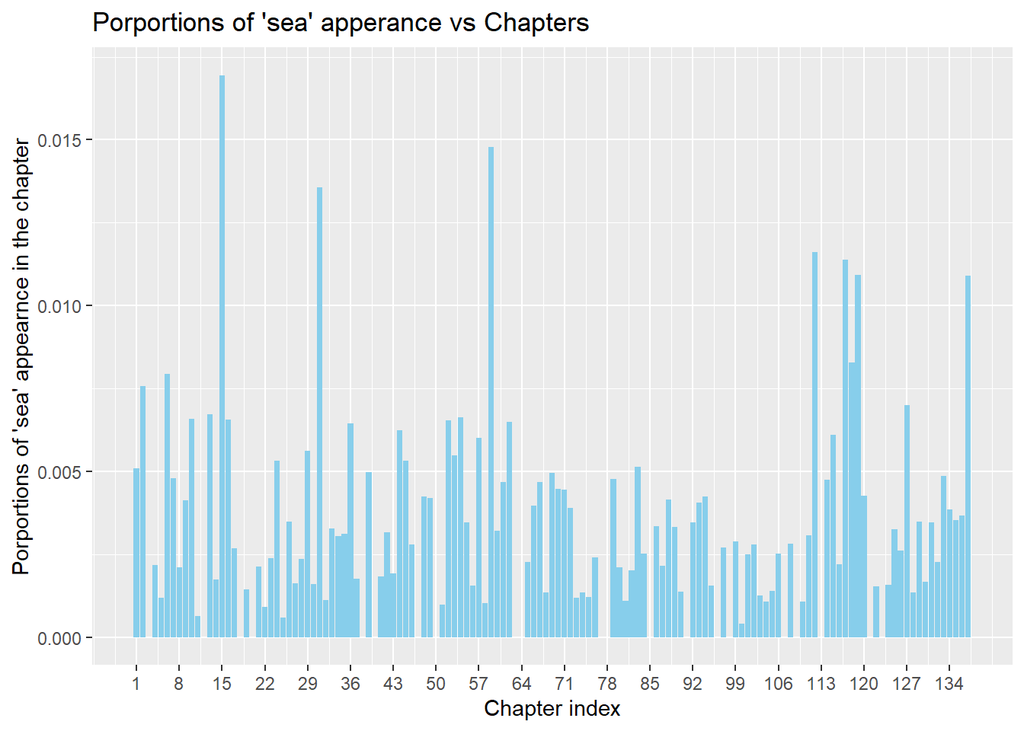

```r
ggplot(df_words_q2_b, aes(x = chapter_index, y = sea_q2_b)) + geom_bar(stat='identity', fill = "skyblue") +scale_x_continuous(breaks =  c(seq(1,137,7))) + ggtitle("Porportions of 'sea' apperance vs Chapters") +
  labs(x = "Chapter index", y = "Porportions of 'sea' appearnce in the chapter")
```

#### conclusion

The plot shows how certain words are used in Moby Dick. “Sea” is used a lot from the start because the story mostly happens at sea. But words like “Ahab” and “Moby” show up less in the middle, then more towards the end. This means they become more important as the story goes on. It’s like seeing the story unfold through the words that are used.